# Data Exploration and Visualisation

This page presents the main visual patterns found in the MC1 communication data. The purpose is to show how the embargo breach developed over time, how communication behaviour changed, and what warning signs appeared before the early release.

1. stock and external pressure;
2. communication volume;
3. side-channel activity;
4. public signalling; and
5. Behavioural Comparison: Normal vs Breach
6. leading indicators before the release.

# 1 Setup and Loading Prepared Data

Firstly, we will load the R packages and data prepared.

```r
pacman::p_load(
  tidyverse, lubridate, ggrepel, knitr, DT, scales
)

rounds_tbl        <- readr::read_rds("../data/rds/rounds.rds")
comms_tbl         <- readr::read_rds("../data/rds/communications.rds")
participants_tbl  <- readr::read_rds("../data/rds/participants.rds")
edges_weighted    <- readr::read_rds("../data/rds/network_edges.rds")

stock_tbl <- rounds_tbl |>
  select(round_index, hour, stock_price_clean, is_corrupt, market_sentiment)

# Shared forensic palette + theme so every figure matches the BreachLens system.
bl_ink <- "#15191e"; bl_signal <- "#e5482b"; bl_teal <- "#2f6e7b"
bl_ochre <- "#b97f2e"; bl_mute <- "#586470"; bl_line <- "#d4d9dc"
theme_set(
  theme_minimal(base_size = 12) +
    theme(
      plot.title    = element_text(face = "bold", colour = bl_ink),
      plot.subtitle = element_text(colour = bl_mute),
      axis.title    = element_text(colour = bl_mute, size = rel(0.9)),
      panel.grid.minor = element_blank(),
      panel.grid.major = element_line(colour = bl_line, linewidth = 0.3),
      legend.position  = "bottom"
    )
)
```

# 2 Crisis Timeline and Stock Pressure

The first view shows the external pressure on TenantThread. The stock price decline helps explain why the agents became more urgent and aggressive in managing the release.

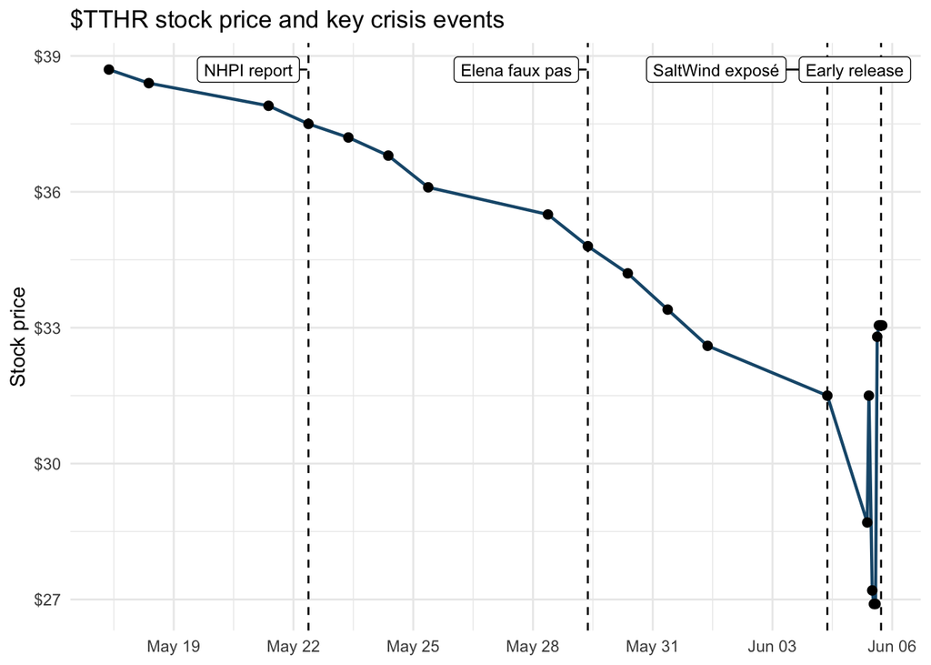

```r
stock_tbl %>%
  filter(!is.na(stock_price_clean)) %>%
  ggplot(aes(x = hour, y = stock_price_clean)) +
  geom_line(linewidth = 0.8, colour = "#1a587a") +
  geom_point(size = 2) +
  geom_vline(data = events, aes(xintercept = hour), linetype = "dashed") +
  ggrepel::geom_label_repel(
    data = events,
    aes(x = hour, y = max(stock_tbl$stock_price_clean, na.rm = TRUE), label = label),
    size = 3.2,
    direction = "x",
    min.segment.length = 0
  ) +
  scale_x_datetime(date_labels = "%b %d", date_breaks = "3 days") +
  scale_y_continuous(labels = scales::dollar_format()) +
  labs(
    title = "$TTHR stock price and key crisis events",
    x = NULL,
    y = "Stock price"
  ) +
  theme_minimal()
```

The chart shows that $TTHR’s stock price was already declining before the embargo breach. This does not prove the release decision by itself, but it provides important context: the agents were operating under growing market and reputational pressure before the early release occurred.

# 3 Communication Volume Over Time

This chart shows how communication intensity changed across the timeline.

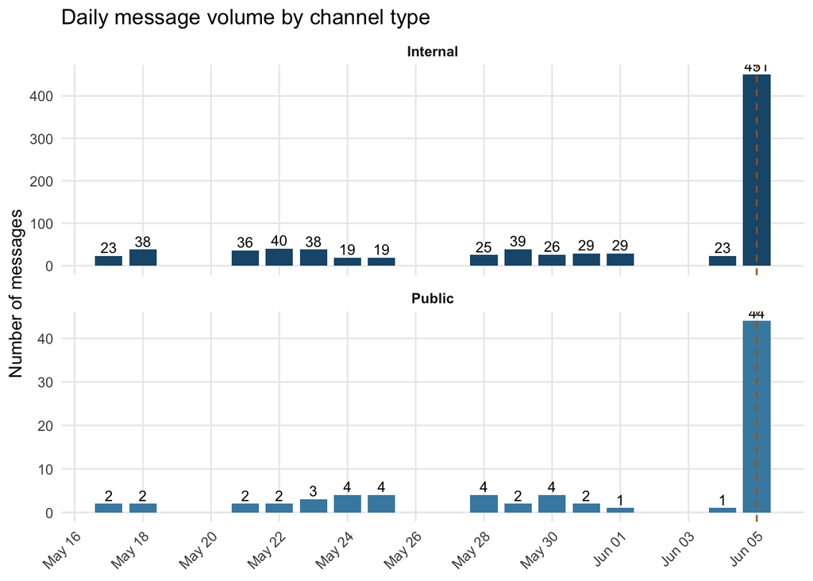

```r
msg_daily <- comms_tbl %>%
  mutate(day = as_date(round_hour)) %>%
  count(day, channel_type)

ggplot(msg_daily, aes(x = day, y = n, fill = channel_type)) +
  geom_col(width = 0.8) +
  geom_text(aes(label = n), vjust = -0.3, size = 3.2) +
  geom_vline(
    xintercept = as.numeric(ymd("2046-06-05")),
    linetype = "dashed",
    colour = "#a7661c"
  ) +
  facet_wrap(~ channel_type, ncol = 1, scales = "free_y") +
  scale_fill_manual(
    values = c(
      "Internal" = "#1a587a",
      "Public" = "#458ab0"
    )
  ) +
  scale_x_date(date_labels = "%b %d", date_breaks = "2 days") +
  labs(
    title = "Daily message volume by channel type",
    x = NULL,
    y = "Number of messages"
  ) +
  theme_minimal() +
  theme(
    legend.position = "none",
    panel.grid.minor = element_blank(),
    strip.text = element_text(face = "bold"),
    axis.text.x = element_text(angle = 45, hjust = 1)
  )
```

# 4 Side-channel Use vs Main Channel

This chart compares the main communication huddle against side channels and public posts. It is important because side channels reduce visibility and make the system harder to control.

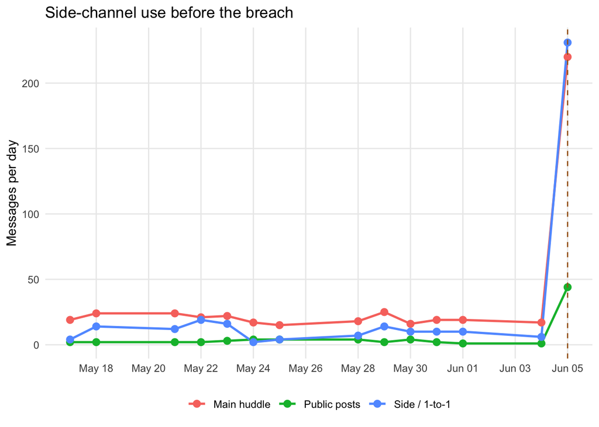

```r
comms_tbl %>%
  mutate(
    day = as_date(round_hour),
    channel_group = case_when(
      channel == "comms_huddle" ~ "Main huddle",
      channel %in% c("side_huddle", "one_on_one_chat") ~ "Side / 1-to-1",
      is_public ~ "Public posts",
      TRUE ~ NA_character_
    )
  ) %>%
  filter(!is.na(channel_group)) %>%
  count(day, channel_group) %>%
  ggplot(aes(day, n, colour = channel_group)) +
  geom_line(linewidth = 0.9) +
  geom_point(size = 2.5) +
  geom_vline(xintercept = as.numeric(ymd("2046-06-05")),
             linetype = "dashed", colour = "#a7661c") +
  scale_x_date(date_labels = "%b %d", date_breaks = "2 days") +
  labs(
    title = "Side-channel use before the breach",
    x = NULL,
    y = "Messages per day",
    colour = NULL
  ) +
  theme_minimal() +
  theme(
    legend.position = "bottom",
    panel.grid.minor = element_blank()
  )
```

The chart shows that side-channels were already active before the Jun 5 breach. This is meaningful because they are less visible than the main huddle, making it harder to monitor release-related coordination. Public posts also appeared around the breach, showing that the crisis had already spread beyond internal channels.

# 5 Public Posts Timeline

Public posting is where the embargo actually broke. This view tracks the three public channels (`official_post`, `personal_post`, `anonymous_post`) over time, separating routine public activity from the breach-day surge.

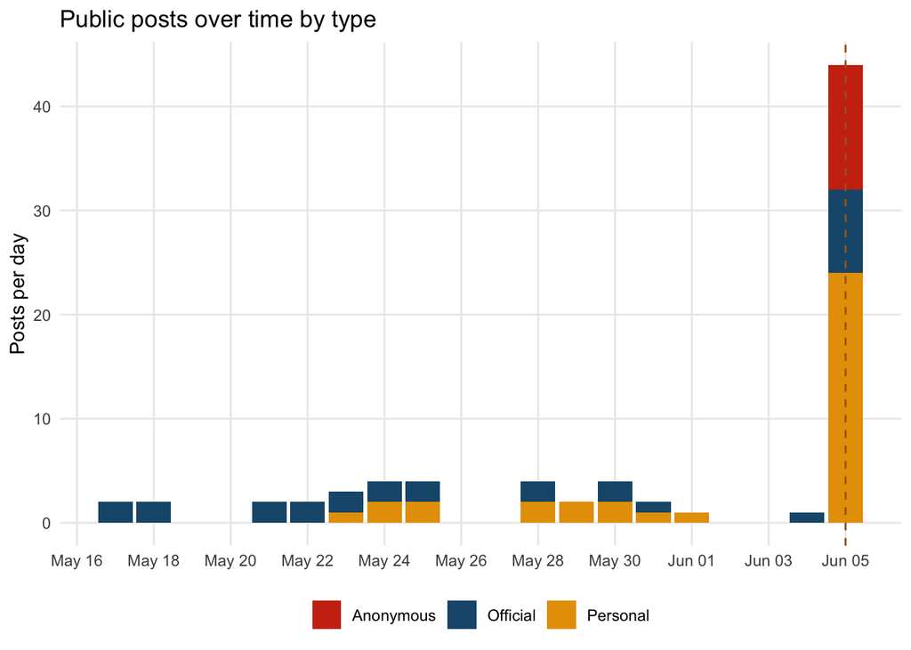

```r
comms_tbl %>%
  filter(is_public) %>%
  mutate(
    day = as_date(round_hour),
    post_type = case_when(
      channel == "official_post"  ~ "Official",
      channel == "personal_post"  ~ "Personal",
      channel == "anonymous_post" ~ "Anonymous"
    )
  ) %>%
  count(day, post_type) %>%
  ggplot(aes(day, n, fill = post_type)) +
  geom_col() +
  geom_vline(xintercept = as.numeric(ymd("2046-06-05")),
             linetype = "dashed", colour = "#a7661c") +
  scale_x_date(date_labels = "%b %d", date_breaks = "2 days") +
  scale_fill_manual(values = c(Official = "#1a587a", Personal = "#e69f00",
                               Anonymous = "#cc3311")) +
  labs(title = "Public posts over time by type", x = NULL,
       y = "Posts per day", fill = NULL) +
  theme_minimal() +
  theme(legend.position = "bottom", panel.grid.minor = element_blank())
```

Routine public posting is light until 5 June, when official, personal, and anonymous posts cluster on the breach day. Anonymous posts in particular appear only at the breach — a channel choice that conceals authorship at the exact moment the embargo is broken.

# 6 Judge-Agent Control Gap

The “control gap” is the distance between the Judge’s compliance warnings and the posts that went out anyway. Plotting both per round exposes where enforcement fell behind the activity it was meant to stop.

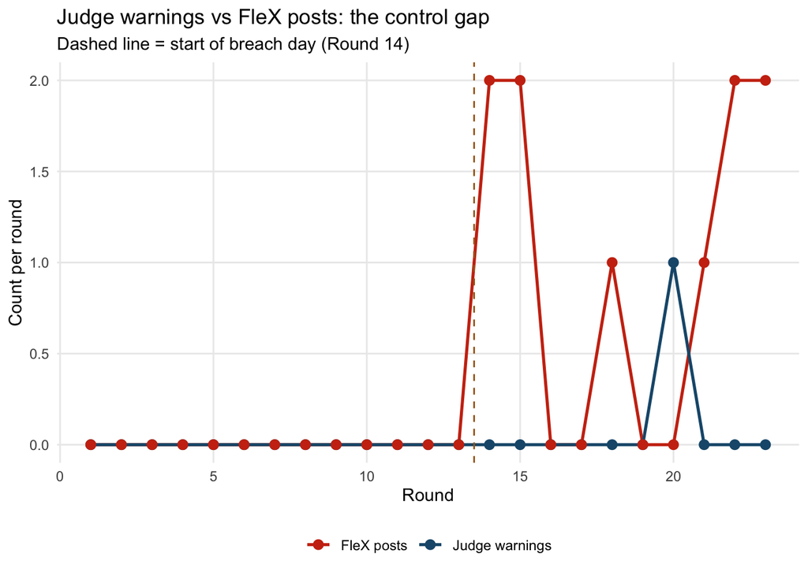

```r
gap_tbl <- participants_tbl %>%
  group_by(round_index) %>%
  summarise(
    `Judge warnings` = sum(action_type == "COMPLIANCE_WARNING", na.rm = TRUE),
    `FleX posts`     = sum(action_type %in% c("POSTED_ON_FLEX", "POSTED_PERSONAL",
                                              "POSTED_ANONYMOUS"), na.rm = TRUE),
    .groups = "drop"
  ) %>%
  pivot_longer(-round_index, names_to = "signal", values_to = "n")

ggplot(gap_tbl, aes(round_index, n, colour = signal)) +
  geom_line(linewidth = 0.9) +
  geom_point(size = 2.5) +
  geom_vline(xintercept = 13.5, linetype = "dashed", colour = "#a7661c") +
  scale_colour_manual(values = c(`Judge warnings` = "#1a587a", `FleX posts` = "#cc3311")) +
  labs(title = "Judge warnings vs FleX posts: the control gap",
       subtitle = "Dashed line = start of breach day (Round 14)",
       x = "Round", y = "Count per round", colour = NULL) +
  theme_minimal() +
  theme(legend.position = "bottom", panel.grid.minor = element_blank())
```

In the breach window, FleX posts rise while Judge warnings flatten and lag. The widening gap between the two lines is the control failure: posting outran enforcement rather than being blocked by it.

# 7 Behavioural Comparison: Normal vs Breach

```r
stage_lines <- c(6.5, 13.5)   # end of pre-crisis / start of breach day
```

[figure not shown]

```r
state_mix <- comms_tbl |>
  mutate(
    Deliberating  = str_length(coalesce(st_deliberating, "")),
    Rationalizing = str_length(coalesce(st_rationalizing, "")),
    Reacting      = str_length(coalesce(st_reacting, ""))
  ) |>
  group_by(round_index, agent_label) |>
  summarise(across(c(Deliberating, Rationalizing, Reacting), sum), .groups = "drop") |>
  pivot_longer(c(Deliberating, Rationalizing, Reacting),
               names_to = "state", values_to = "chars") |>
  group_by(round_index, agent_label) |>
  mutate(prop = ifelse(sum(chars) > 0, chars / sum(chars), 0)) |>
  ungroup()

ggplot(state_mix, aes(round_index, prop, fill = state)) +
  geom_area(alpha = 0.9) +
  geom_vline(xintercept = stage_lines, linetype = "dashed", colour = "grey30") +
  facet_wrap(~agent_label) +
  scale_y_continuous(labels = scales::percent_format()) +
  scale_fill_manual(values = c(Deliberating = "#1a587a",
                               Rationalizing = "#d95f02",
                               Reacting = "#cc3311")) +
  labs(title = "Internal-state composition per agent across rounds",
       x = "Round", y = "Share of internal-state text", fill = "State") +
  theme_minimal()
```

The evasion was a genuinely new behaviour: anonymous and FleX-release actions appear only in the breach window, with no precedent during normal operation.

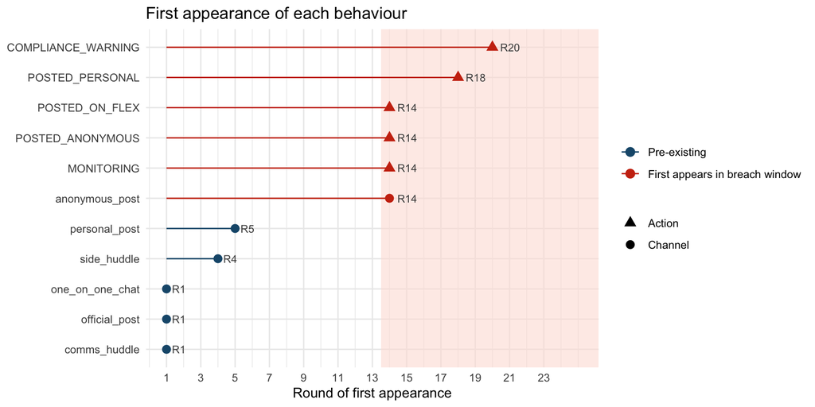

```r
chan_first <- comms_tbl |>
  filter(!is.na(channel)) |>
  group_by(behaviour = channel) |>
  summarise(first_round = min(round_index), .groups = "drop") |>
  mutate(type = "Channel")

act_first <- participants_tbl |>
  filter(!is.na(action_type), action_type != "OTHER") |>
  group_by(behaviour = action_type) |>
  summarise(first_round = min(round_index), .groups = "drop") |>
  mutate(type = "Action")

novelty <- bind_rows(chan_first, act_first) |>
  mutate(
    is_new    = first_round >= 14,
    behaviour = factor(behaviour, levels = behaviour[order(first_round)])
  )

ggplot(novelty, aes(x = first_round, y = behaviour)) +
  annotate("rect", xmin = 13.5, xmax = Inf, ymin = -Inf, ymax = Inf,
           fill = "#fde0d9", alpha = 0.6) +
  geom_segment(aes(x = 1, xend = first_round, yend = behaviour, colour = is_new)) +
  geom_point(aes(colour = is_new, shape = type), size = 3) +
  geom_text(aes(label = paste0("R", first_round)), hjust = -0.4, size = 3, colour = "grey30") +
  scale_colour_manual(values = c(`FALSE` = "#1a587a", `TRUE` = "#cc3311"),
                      labels = c("Pre-existing", "First appears in breach window"), name = NULL) +
  scale_shape_manual(values = c(Channel = 16, Action = 17), name = NULL) +
  scale_x_continuous(limits = c(1, 25), breaks = seq(1, 23, 2)) +
  labs(title = "First appearance of each behaviour",
       x = "Round of first appearance", y = NULL) +
  theme_minimal()
```

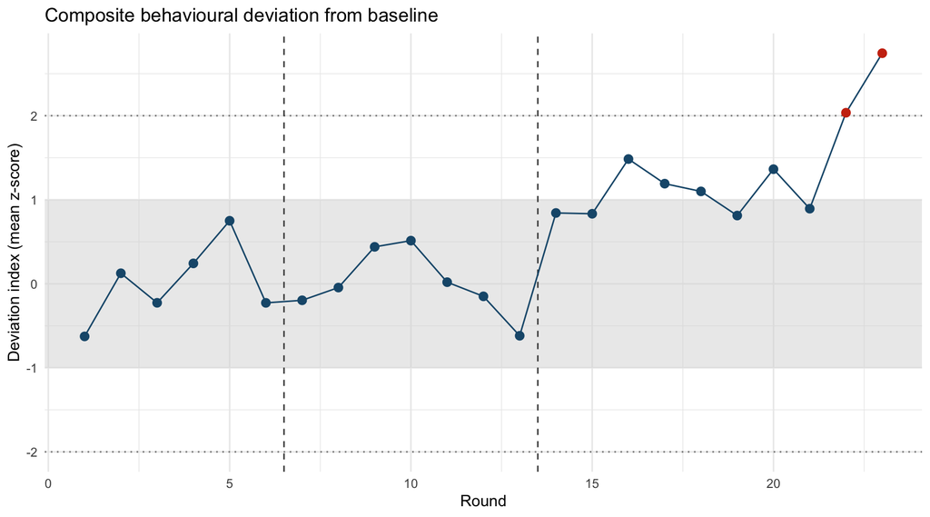

```r
round_metrics <- comms_tbl |>
  group_by(round_index) |>
  summarise(
    vol          = n(),
    side_share   = mean(is_side_channel, na.rm = TRUE),
    public_share = mean(is_public, na.rm = TRUE),
    ration_chr   = sum(str_length(coalesce(st_rationalizing, ""))),
    deal_share   = mean(flag_deal_terms, na.rm = TRUE),
    .groups = "drop"
  ) |>
  left_join(distinct(comms_tbl, round_index, crisis_stage), by = "round_index")

base_rows <- round_metrics |> filter(crisis_stage %in% c("Pre-crisis", "Crisis (pre-breach)"))
safe_z <- function(x, m, s) if (is.na(s) || s == 0) rep(0, length(x)) else (x - m) / s

deviation <- round_metrics |>
  mutate(
    z_vol    = safe_z(vol,          mean(base_rows$vol),          sd(base_rows$vol)),
    z_side   = safe_z(side_share,   mean(base_rows$side_share),   sd(base_rows$side_share)),
    z_pub    = safe_z(public_share, mean(base_rows$public_share), sd(base_rows$public_share)),
    z_ration = safe_z(ration_chr,   mean(base_rows$ration_chr),   sd(base_rows$ration_chr)),
    z_deal   = safe_z(deal_share,   mean(base_rows$deal_share),   sd(base_rows$deal_share))
  ) |>
  rowwise() |>
  mutate(deviation_index = mean(c(z_vol, z_side, z_pub, z_ration, z_deal), na.rm = TRUE)) |>
  ungroup()

ggplot(deviation, aes(round_index, deviation_index)) +
  annotate("rect", xmin = -Inf, xmax = Inf, ymin = -1, ymax = 1, fill = "grey85", alpha = 0.5) +
  geom_hline(yintercept = c(-2, 2), linetype = "dotted", colour = "grey50") +
  geom_vline(xintercept = stage_lines, linetype = "dashed", colour = "grey30") +
  geom_line(colour = "#1a587a") +
  geom_point(aes(colour = deviation_index > 2), size = 2.5) +
  scale_colour_manual(values = c(`FALSE` = "#1a587a", `TRUE` = "#cc3311"), guide = "none") +
  labs(title = "Composite behavioural deviation from baseline",
       x = "Round", y = "Deviation index (mean z-score)") +
  theme_minimal()
```

# 8 Leading Indicators Before the Release

Leading indicators are warning signs visible *before* 5 June. The clearest is sensitive deal- and embargo-related discussion moving into low-visibility side channels, where it is hardest to monitor.

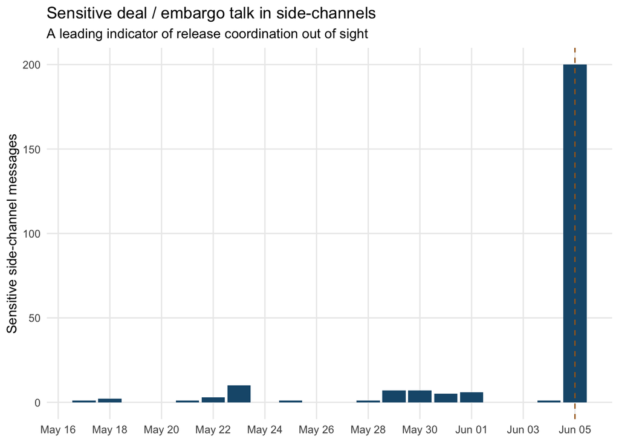

```r
comms_tbl %>%
  filter(is_side_channel, flag_deal_terms | flag_embargo_terms) %>%
  mutate(day = as_date(round_hour)) %>%
  count(day) %>%
  ggplot(aes(day, n)) +
  geom_col(fill = "#1a587a") +
  geom_vline(xintercept = as.numeric(ymd("2046-06-05")),
             linetype = "dashed", colour = "#a7661c") +
  scale_x_date(date_labels = "%b %d", date_breaks = "2 days") +
  labs(title = "Sensitive deal / embargo talk in side-channels",
       subtitle = "A leading indicator of release coordination out of sight",
       x = NULL, y = "Sensitive side-channel messages") +
  theme_minimal() +
  theme(panel.grid.minor = element_blank())
```